# Exercise 1 (20 minutes)

You practice: the naïve comparison — on a new outcome, support for an anti-discrimination law. When you're done, assist some of the others …

1. Download the **APAD** dataset from Absalon into your project folder, then copy in this starter code — the same preparation as on the slides:

```r
pacman::p_load(tidyverse, estimatr, modelsummary)
load("APAD.RData") # from your project folder
```

```r
APAD <- APAD %>%
  mutate(
    news    = news_hrs * 60 + news_mins,
    news_yn = case_when( # reads news?
      news < 5 ~ 0,      # 0 if less than 5 minutes
      news >= 5 ~ 1)     # 1 if 5 minutes or more
  )
```

> **Stuck?**
> - Did `pacman::p_load(...)` run without red errors? Fix that first.
> - **`load()` can't find the file?** `APAD.RData` must sit **in your project folder** — the same folder as your `.Rproj`. Check the *Files* pane in RStudio.
> - Odd results? *Session → Restart R*, then rerun from the top.
> - Still stuck? Ask in the [t-R-ouble forum](https://absalon.ku.dk/courses/70545/discussion_topics/563046?module_item_id=2037268) on Absalon.
2. The variable `antidiscr_law` asks how good it is for a country to have a law against ethnic discrimination at work: (1) Very bad … (5) Very good. **Write it yourself:** a weighted scatter plot with `news` on the x-axis and `antidiscr_law` on the y-axis, dot size = the weight `gewFAKT`, and a weighted regression line.

Map `size = gewFAKT` inside `geom_point()` and `weight = gewFAKT` inside `geom_smooth(method = "lm")`. Hide the size legend with `theme(legend.position = "none")`.

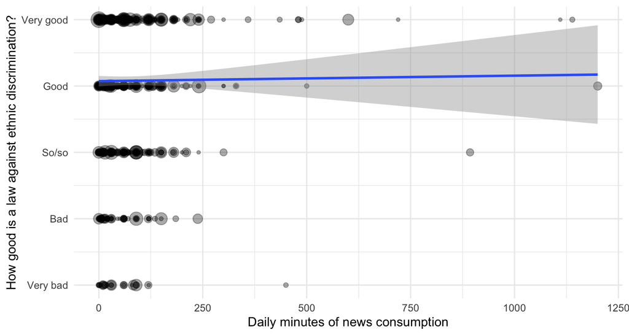

```r
ggplot(APAD, aes(y = antidiscr_law, x = news)) +
  geom_point(aes(size = gewFAKT), alpha = 1/3) +
  geom_smooth(aes(weight = gewFAKT), method = "lm") +
  scale_y_continuous(breaks = 1:5,
    labels = c("Very bad", "Bad", "So/so", "Good", "Very good")) +
  labs(y = "How good is a law against ethnic discrimination?",
       x = "Daily minutes of news consumption") +
  theme_minimal() + theme(legend.position = "none")
```

3. A day has only 1,440 minutes, yet some respondents reported implausibly high news time. **Cap** everyone above 4 hours (240 min) at 240, then redraw. What does this cleaning step do?

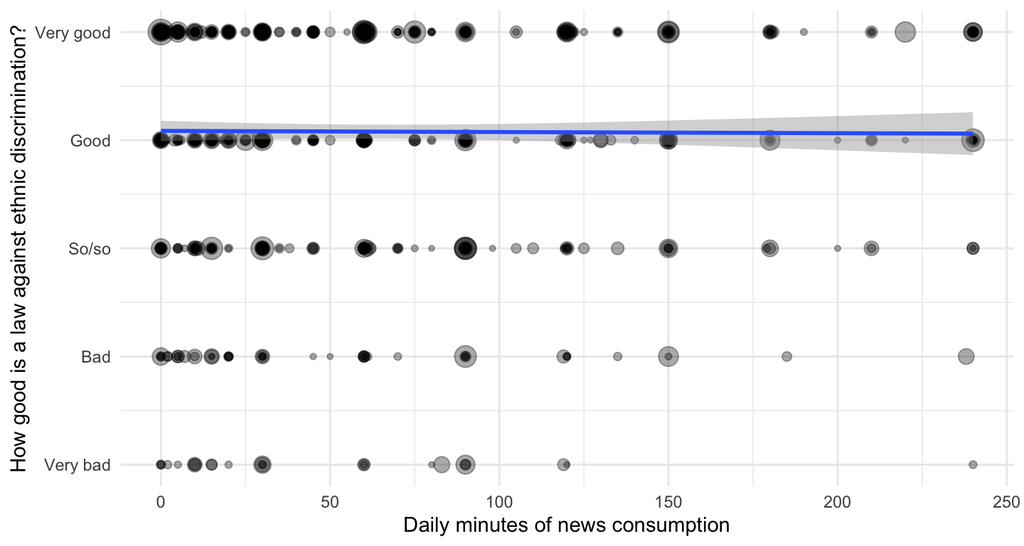

```r
APAD <- APAD %>%
  mutate(news = case_when(news > 240 ~ 240, # cap at 4 hours
                          TRUE ~ news))

ggplot(APAD, aes(y = antidiscr_law, x = news)) +
  geom_point(aes(size = gewFAKT), alpha = 1/3) +
  geom_smooth(aes(weight = gewFAKT), method = "lm") +
  scale_y_continuous(breaks = 1:5,
    labels = c("Very bad", "Bad", "So/so", "Good", "Very good")) +
  labs(y = "How good is a law against ethnic discrimination?",
       x = "Daily minutes of news consumption") +
  theme_minimal() + theme(legend.position = "none")
```

4. **Before you compute:** using the binary `news_yn`, do you expect news readers to support the law *more* or *less* than non-readers — and strongly?
5. Now run the weighted OLS `antidiscr_law ~ news_yn` and read off:
- News readers support the law by points more/less than non-readers (two digits; a leading minus and point *or* comma are fine).
- Its standard error is .

```r
ols_law <- lm_robust(antidiscr_law ~ news_yn, weights = gewFAKT, data = APAD)

modelsummary(list("Anti-discr. law" = ols_law), stars = TRUE,
             coef_rename = c("news_yn" = "Reads news"),
             gof_map = c("nobs", "r.squared"))
```

|  | Anti-discr. law |
| --- | --- |
| (Intercept) | 4.338*** |
|  | (0.157) |
| Reads news | -0.293+ |
|  | (0.170) |
| Num.Obs. | 1060 |
| R2 | 0.008 |

+ p < 0.1, * p < 0.05, ** p < 0.01, *** p < 0.001

**Bonus (for the fast):** news readers and non-readers differ in age. Add `age` to the model (`antidiscr_law ~ news_yn + age`). Does the `news_yn` coefficient change once age is held constant?

```r
modelsummary(
  list("Naïve" = lm_robust(antidiscr_law ~ news_yn, weights = gewFAKT, data = APAD),
       "+ age" = lm_robust(antidiscr_law ~ news_yn + age, weights = gewFAKT, data = APAD)),
  stars = TRUE, coef_rename = c("news_yn" = "Reads news"),
  gof_map = c("nobs", "r.squared"))
```

|  | Naïve | + age |
| --- | --- | --- |
| (Intercept) | 4.338*** | 4.215*** |
|  | (0.157) | (0.212) |
| Reads news | -0.293+ | -0.310+ |
|  | (0.170) | (0.166) |
| age |  | 0.003 |
|  |  | (0.004) |
| Num.Obs. | 1060 | 1060 |
| R2 | 0.008 | 0.010 |

+ p < 0.1, * p < 0.05, ** p < 0.01, *** p < 0.001

Adjusting for one confounder (age) already nudges the coefficient — a first taste of the multiple regression to come. But age is only *one observed* difference; unobserved ones remain.